# Proyecto-Mineria_de_Datos-ajustado

## Proyecto

Profesor: Ing. Luis Diego Chacón Gómez  
Curso: SINT-616- Minería de Datos M4-2025  
Estudiante: Natalia Bonilla V.

La cadena de supermercados COMPRO instalada en el país, requiere poder *predecir* el monto de ventas de un producto a partir de una serie de características. Para ello, le ha proporcionado una tabla de datos correspondiente a una muestra de productos con las siguientes columnas:

- **producto:** descripción del producto vendido.
- **sede:** ubicación geográfica donde se encuentra la sede del supermercado.
- **precio:** valor del precio unitario.
- **publicidad:** monto invertido en publicidad.
- **descuento:** porcentaje de descuento aplicado en el producto.
- **popularidad:** popularidad del producto en la cadena de supermercados.
- **tiempo_en_estante:** cantidad de días que dura en promedio un producto en estantería.
- **stock_inicial:** cantidad de productos en stock al inicio del periodo.
- **promocion:** 1 si el producto tiene promoción, 0 el producto no tiene promoción.
- **demanda_regional:** valor de demanda en la región.
- **ventas:** total de ventas del producto.

## > Carga de paquetes y lilbrerías

```python
from sklearn.preprocessing import StandardScaler # normalizar variable#s
import seaborn as sns # visualizaciones estadísticas
from sklearn.model_selection import train_test_split # separar data en entrenamiento y validación para modelos
from sklearn.metrics import classification_report, confusion_matrix # mostrar matriz de confusión para evaluar modelos
from sklearn.linear_model import LinearRegression # aplicar modelos de regresión lineal
from sklearn.metrics import mean_squared_error, r2_score, mean_absolute_error # mostrar métricas para evaluar modelos
```

```python
import pandas as pd  # Librería para manejar tablas y datos
import numpy as np # Para operaciones matemáticas y generación de datos
import matplotlib.pyplot as plt # realizar gráficas
df = pd.read_excel('ventas_supermercado.xlsx')
```

```python
df.head()
```

|  | producto | sede | precio | publicidad | descuento | popularidad | tiempo_en_estante | stock_inicial | promocion | demanda_regional | ventas |
| --- | --- | --- | --- | --- | --- | --- | --- | --- | --- | --- | --- |
| 0 | Queso | Puntarenas | 2.21 | 1247.21 | 0.08 | 4.0 | 29.8 | 64 | 0 | 23.130754 | 98.60 |
| 1 | Cereal | Puntarenas | 3.29 | 667.96 | 0.06 | 6.0 | 25.8 | 132 | 1 | 17.722831 | 165.81 |
| 2 | Café | Heredia | 7.90 | 880.55 | 0.10 | 8.0 | 23.5 | 97 | 1 | 26.530718 | 182.41 |
| 3 | Jugo | San José | 1.94 | 513.63 | 0.14 | 1.0 | 29.7 | 176 | 0 | 15.756335 | 70.00 |
| 4 | Queso | Puntarenas | 5.69 | 1935.44 | 0.09 | 4.0 | 24.4 | 95 | 0 | 21.570997 | 117.18 |

## > Preprocesamiento de datos

### >> Inspección inicial

```python
df.columns
```

```
Index(['producto', 'sede', 'precio', 'publicidad', 'descuento', 'popularidad',
       'tiempo_en_estante', 'stock_inicial', 'promocion', 'demanda_regional',
       'ventas'],
      dtype='object')
```

- Se identifican las variables disponibles del conjunto de datos:
  - 'producto'
  - 'sede'
  - 'precio'
  - 'publicidad'
  - 'descuento'
  - 'popularidad'
  - 'tiempo_en_estante'
  - 'stock_inicial'
  - 'promocion'
  - 'demanda_regional'
  - 'ventas'

```python
df.shape
```

```
(2500, 11)
```

- Se identifica la dimension del conjunto de datos -> 2500 filas y 11 columnas

```python
df.dtypes
```

```
producto              object
sede                  object
precio               float64
publicidad           float64
descuento            float64
popularidad          float64
tiempo_en_estante    float64
stock_inicial          int64
promocion              int64
demanda_regional     float64
ventas               float64
dtype: object
```

- Identificamos el tipo de dato para cada columna/variable que contiene el conjunto de datos.  
  Acá podemos ver que 7 de las variables son float, tenemos 2 variables con numeros enteros o int y 2 variables object que en este caso serian del tipo de dato string, por lo que podemos determinar y viendo su valor que son variables categóricas

```python
df.duplicated()
```

```
0       False
1       False
2       False
3       False
4       False
        ...
2495    False
2496    False
2497    False
2498    False
2499    False
Length: 2500, dtype: bool
```

```python
df.info()
```

```
<class 'pandas.core.frame.DataFrame'>
RangeIndex: 2500 entries, 0 to 2499
Data columns (total 11 columns):
 #   Column             Non-Null Count  Dtype
---  ------             --------------  -----
 0   producto           2500 non-null   object
 1   sede               2500 non-null   object
 2   precio             2500 non-null   float64
 3   publicidad         2500 non-null   float64
 4   descuento          2500 non-null   float64
 5   popularidad        2375 non-null   float64
 6   tiempo_en_estante  2350 non-null   float64
 7   stock_inicial      2500 non-null   int64
 8   promocion          2500 non-null   int64
 9   demanda_regional   2500 non-null   float64
 10  ventas             2500 non-null   float64
dtypes: float64(7), int64(2), object(2)
memory usage: 215.0+ KB
```

```python
df.describe()
```

|  | precio | publicidad | descuento | popularidad | tiempo_en_estante | stock_inicial | promocion | demanda_regional | ventas |
| --- | --- | --- | --- | --- | --- | --- | --- | --- | --- |
| count | 2500.000000 | 2500.000000 | 2500.000000 | 2375.000000 | 2350.000000 | 2500.000000 | 2500.000000 | 2500.000000 | 2500.000000 |
| mean | 5.713412 | 1023.171620 | 0.150848 | 4.866526 | 25.085660 | 174.473200 | 0.302400 | 21.921443 | 125.181980 |
| std | 2.444838 | 541.969211 | 0.085605 | 3.125882 | 3.724564 | 71.619451 | 0.459389 | 15.582283 | 48.299292 |
| min | 1.500000 | 100.460000 | 0.000000 | 0.000000 | 15.100000 | 50.000000 | 0.000000 | -12.954921 | 70.000000 |
| 25% | 3.600000 | 556.192500 | 0.080000 | 2.000000 | 22.400000 | 112.000000 | 0.000000 | 9.788406 | 77.382500 |
| 50% | 5.690000 | 1011.610000 | 0.150000 | 5.000000 | 25.000000 | 175.000000 | 0.000000 | 20.926433 | 118.985000 |
| 75% | 7.800000 | 1481.565000 | 0.222500 | 7.500000 | 27.900000 | 236.000000 | 1.000000 | 33.195186 | 160.605000 |
| max | 10.000000 | 1998.490000 | 0.300000 | 10.000000 | 35.700000 | 299.000000 | 1.000000 | 67.525636 | 280.890000 |

```python
print("Medidas de Tendencia Central y de Dispersión:")
numeric_var = df.drop(['producto', 'sede'], axis=1)

# Calculate measures of central tendency
central_tendency = {
    'Suma': (numeric_var.sum()).round(2),
    'Moda': (numeric_var.mode().iloc[0]).round(2) # mode() can return multiple values, take the first one
}

# Calculate measures of dispersion
dispersion = {
    'Rango': (numeric_var.max() - numeric_var.min()).round(2),
    'R. Intercuartílico': (numeric_var.quantile(0.75) - numeric_var.quantile(0.25)).round(2),
    'Varianza': numeric_var.var().round(2),
    'Coef. Variación': (numeric_var.std() / numeric_var.mean()).round(2)
}

# Combine into a single DataFrame
summary_df = pd.DataFrame(central_tendency)
summary_df = pd.concat([summary_df, pd.DataFrame(dispersion)], axis=1)

summary_df
```

```
Medidas de Tendencia Central y de Dispersión:
```

|  | Suma | Moda | Rango | R. Intercuartílico | Varianza | Coef. Variación |
| --- | --- | --- | --- | --- | --- | --- |
| precio | 14283.53 | 7.01 | 8.50 | 4.20 | 5.98 | 0.43 |
| publicidad | 2557929.05 | 100.46 | 1898.03 | 925.37 | 293730.63 | 0.53 |
| descuento | 377.12 | 0.28 | 0.30 | 0.14 | 0.01 | 0.57 |
| popularidad | 11558.00 | 0.00 | 10.00 | 5.50 | 9.77 | 0.64 |
| tiempo_en_estante | 58951.30 | 23.20 | 20.60 | 5.50 | 13.87 | 0.15 |
| stock_inicial | 436183.00 | 130.00 | 249.00 | 124.00 | 5129.35 | 0.41 |
| promocion | 756.00 | 0.00 | 1.00 | 1.00 | 0.21 | 1.52 |
| demanda_regional | 54803.61 | -12.95 | 80.48 | 23.41 | 242.81 | 0.71 |
| ventas | 312954.95 | 70.00 | 210.89 | 83.22 | 2332.82 | 0.39 |

```python
df_count_promocion = df['promocion'].value_counts().to_frame('Conteo')
df_count_promocion
```

| promocion | Conteo |
| --- | --- |
| 0 | 1744 |
| 1 | 756 |

## Interpretación de Medidas de Tendencia

**Acá podemos ver una descripcion general de las medidas de tendencia central y de dispersión y podemos determinar qué:**

**'Precio'** En promedio del Precio ronda el: 5.71, y éste se desvía del promedio alrededor de: 2.44, además que la mitad o menos tiene el precio: 5.69 valor que pertenece a la mediana o Q2. El rango intercuartil indica que la mitad central del precio (entre 7.80 y 3.60) se encuentra dispersa en un rango de 4.20.

**'Publicidad'** En promedio el monto invertido en publicidad ronda los: 1023.17, y éste se desvía del promedio alrededor de: 541.97, además que la mitad o menos del monto invertido en publicidad es: 1011.61, valor que pertenece a la mediana o Q2. El rango intercuartil indica que la mitad central del publicidad (entre 556.19 y 1481.57) se encuentra dispersa en un rango de 925.37.

**'Descuento'** En promedio el porcentaje de descuento aplicado al producto ronda el: 15.08%, y éste se desvía del promedio alrededor de: 8.56%, además que la mitad o menos tiene de descuento: 15%, valor que pertenece a la mediana o Q2. El rango intercuartil indica que la mitad central del descuento (entre 22.25% y 8%) se encuentra dispersa en un rango de 14.25%

**'Popularidad'** En promedio la Popularidad del producto ronda el: 4.87, y éste se desvía del promedio alrededor de: 3.12, además que la mitad o menos tiene de popularidad: 5, valor que pertenece a la mediana o Q2. El rango intercuartil indica que la mitad central de la popularidad (entre 7.5 y 2) se encuentra dispersa en un rango de 5.5

**'Tiempo_en_estante'** En promedio de la cantidad de días que dura el producto en el estante ronda el: 25.08, y éste se desvía del promedio alrededor de: 3.72, además que la mitad o menos tiene de tiempo en estante: 25, valor que pertenece a la mediana o Q2. El rango intercuartil indica que la mitad central del tiempo en estante (entre 27.9 y 22.4) se encuentra dispersa en un rango de 5.5

**'Stock_inicial'** En promedio la cantidad de productos al inicio del periodo ronda el: 174.47, y éste se desvía del promedio alrededor de: 71.62, además que la mitad o menos tiene del stock inicial: 175, valor que pertenece a la mediana o Q2. El rango intercuartil indica que la mitad central del stock inicial (entre 236 y 112) se encuentra dispersa en un rango de 124.

**'Promocion'** Promocion es una variable categórica aunque se compone de 0 y 1. Su significado es:

- 0: Sin promocion
- 1: Con promocion.

Por lo que la moda de promocion es: 0.  
Cantidad de productos sin promocion: 1744.  
Cantidad de productos con promocion: 756.

**'demanda_regional'** En promedio el valor que demanda la región ronda los: 21.92, y éste se desvía del promedio alrededor de: 15.58, además que la mitad o menos tiene de demanda regional: 20.93, valor que pertenece a la mediana o Q2. El rango intercuartil indica que la mitad central de la demanda regional (entre 33.2 y 9.79) se encuentra dispersa en un rango de 23.41

**'ventas'** En promedio el ventas ronda el: 125.18, y éste se desvía del promedio alrededor de: 48.3, además que la mitad o menos tiene de ventas: 119, valor que pertenece a la mediana o Q2. El rango intercuartil indica que la mitad central de ventas (entre 160.6 y 77.38) se encuentra dispersa en un rango de 83.22

### >> Verificar distribuciones de los datos

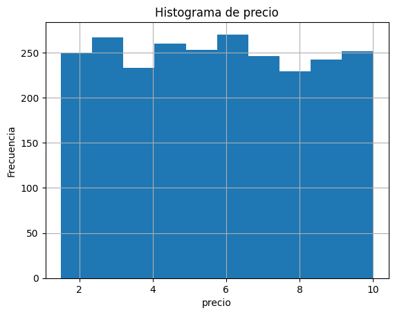

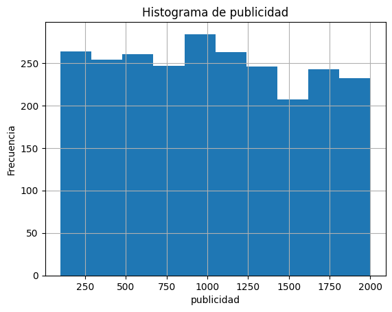

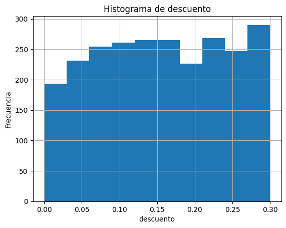

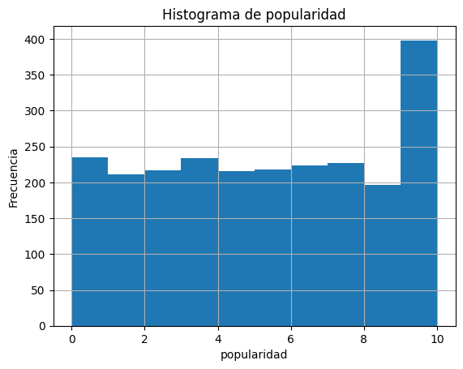

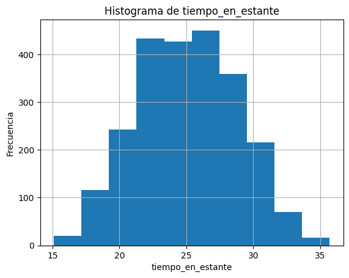

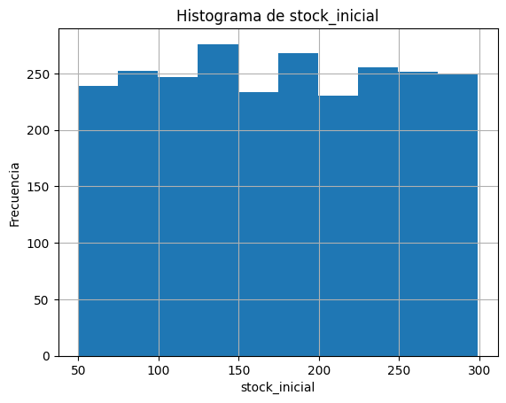

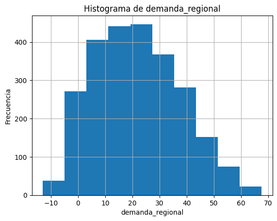

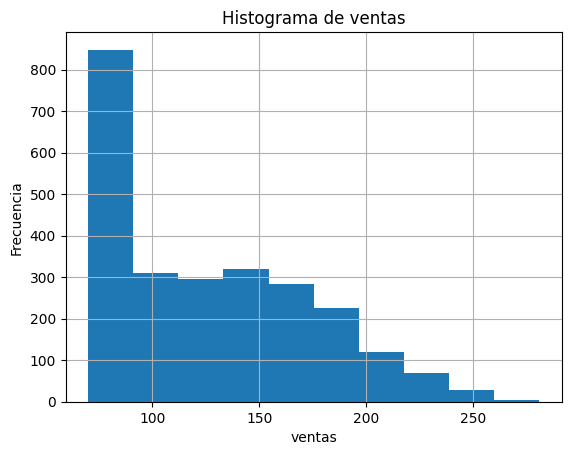

```python
numeric_var = df.drop(['producto', 'sede', 'promocion'], axis=1)
for i in numeric_var:
    plt.figure()
    df[i].hist()
    plt.title(f'Histograma de {i}')
    plt.xlabel(i)
    plt.ylabel('Frecuencia')
    plt.show()
```

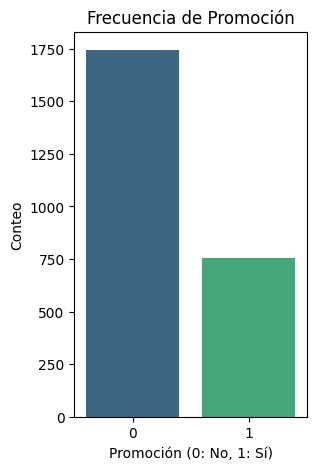

```python
plt.figure(figsize=(3, 5))
ax = sns.countplot(x='promocion', data=df, palette='viridis', hue='promocion', legend=False)
plt.title('Frecuencia de Promoción')
plt.xlabel('Promoción (0: No, 1: Sí)')
plt.ylabel('Conteo')
plt.show()
```

```python
qualitative_var_prom = df.groupby(['producto', 'promocion']).size().reset_index(name='Frecuencia')
qualitative_var_prom.head(10)
```

|  | producto | promocion | Frecuencia |
| --- | --- | --- | --- |
| 0 | Aceite | 0 | 173 |
| 1 | Aceite | 1 | 65 |
| 2 | Arroz | 0 | 181 |
| 3 | Arroz | 1 | 75 |
| 4 | Café | 0 | 158 |
| 5 | Café | 1 | 90 |
| 6 | Cereal | 0 | 166 |
| 7 | Cereal | 1 | 74 |
| 8 | Galletas | 0 | 171 |
| 9 | Galletas | 1 | 82 |

```python
pivot_product_prom = pd.pivot_table(qualitative_var_prom, index='producto', columns='promocion', values='Frecuencia', fill_value=0)
pivot_product_prom
```

| promocion producto | 0 | 1 |
| --- | --- | --- |
| Aceite | 173.0 | 65.0 |
| Arroz | 181.0 | 75.0 |
| Café | 158.0 | 90.0 |
| Cereal | 166.0 | 74.0 |
| Galletas | 171.0 | 82.0 |
| Huevos | 173.0 | 70.0 |
| Jugo | 183.0 | 81.0 |
| Leche | 198.0 | 71.0 |
| Pan | 167.0 | 80.0 |
| Queso | 174.0 | 68.0 |

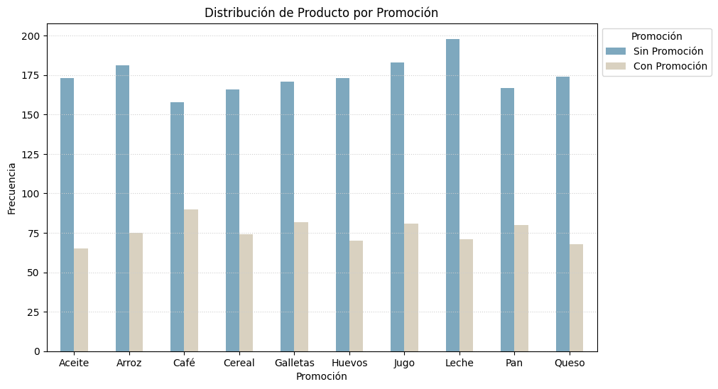

```python
sede_status_color = ['#7EA8BE', '#D9D1C0']
plt.figure(figsize=(10, 6))
pivot_product_prom.plot(kind='bar', stacked=False, figsize=(10, 6), color=sede_status_color)
plt.title('Distribución de Producto por Promoción')
plt.xlabel('Promoción')
plt.ylabel('Frecuencia')
plt.xticks(rotation=0)
plt.legend(title='Promoción', loc='upper left', bbox_to_anchor=(1, 1),
           labels=['Sin Promoción', 'Con Promoción'])
plt.grid(color='#CFCFCF', linestyle='dotted', axis='y')  # Líneas verticales
plt.show()
```